# CAPSTONE PROJECT TOPIC:

# PREDICTING BUILDING INSURANCE CLAIMS

```
           BY
   IRENE UFUOMA AYAKAZI
```

# PROJECT OVERVIEW

- In the insurance industry, accurately assessing risk is crucial for profitability and customer satisfaction. This project focuses on developing a predictive model that **determines the likelihood of a building filing at least one insurance claim during its insured period**. By leveraging historical data on building characteristics and claim history, the model aims to support **Olusola Insurance** in making data-driven underwriting decisions, optimizing risk assessment, and reducing potential losses.
- As the Lead Data Analyst, the goal is to build a robust machine learning pipeline that includes data preprocessing, exploratory data analysis (EDA), feature engineering, model experimentation, and evaluation. The final deliverable is a predictive model that outputs the probability of a claim, enabling the insurer to proactively manage high-risk policies.
- This project not only demonstrates technical proficiency in data science and machine learning but also emphasizes real-world impact by addressing a critical business need in the insurance domain.

# DATASET DESCRIPTION

.The dataset contains historical records of insured buildings, including their physical attributes, location, and claim status. Each row represents a unique insurance policy for a building observed over a specific period. The dataset includes both **numerical and categorical features**, which require preprocessing and transformation for modeling.

### PROBLEM STATEMENT

- The primary objective of this project is to **build a predictive model that estimates the probability of a building filing at least one insurance claim during its insured period**. The model will use various building characteristics and contextual information to make this prediction.

### KEY GOALS :

- Identify the most influential features contributing to insurance claims.
- Develop and compare multiple machine learning models to predict the Claim variable.
- Evaluate model performance using appropriate classification metrics.
- Provide actionable insights to help Olusola Insurance improve underwriting strategies and risk management.

```python
# STEP 1 Import Required Libraries
import pandas as pd
import numpy as np
import os
import matplotlib.pyplot as plt
import seaborn as sns

from rich.console import Console
from rich.table import Table

console = Console()
```

```python
#  LOAD DATASET
df = pd.read_csv("Train_data.csv")
```

```python
# VIEW 5 FIRST ROW
df = pd.read_csv("Train_data.csv")
df.head()
```

|  | Customer Id | YearOfObservation | Insured_Period | Residential | Building_Painted | Building_Fenced | Garden | Settlement | Building Dimension | Building_Type | Date_of_Occupancy | NumberOfWindows | Geo_Code | Claim |
| --- | --- | --- | --- | --- | --- | --- | --- | --- | --- | --- | --- | --- | --- | --- |
| 0 | H14663 | 2013 | 1.0 | 0 | N | V | V | U | 290.0 | 1 | 1960.0 | . | 1053 | 0 |
| 1 | H2037 | 2015 | 1.0 | 0 | V | N | O | R | 490.0 | 1 | 1850.0 | 4 | 1053 | 0 |
| 2 | H3802 | 2014 | 1.0 | 0 | N | V | V | U | 595.0 | 1 | 1960.0 | . | 1053 | 0 |
| 3 | H3834 | 2013 | 1.0 | 0 | V | V | V | U | 2840.0 | 1 | 1960.0 | . | 1053 | 0 |
| 4 | H5053 | 2014 | 1.0 | 0 | V | N | O | R | 680.0 | 1 | 1800.0 | 3 | 1053 | 0 |

```python
# VIEW 5 LAST ROW
df = pd.read_csv("Train_data.csv")
df.tail(15)
```

|  | Customer Id | YearOfObservation | Insured_Period | Residential | Building_Painted | Building_Fenced | Garden | Settlement | Building Dimension | Building_Type | Date_of_Occupancy | NumberOfWindows | Geo_Code | Claim |
| --- | --- | --- | --- | --- | --- | --- | --- | --- | --- | --- | --- | --- | --- | --- |
| 7145 | H2241 | 2014 | 1.000000 | 0 | V | V | V | U | NaN | 2 | 1985.0 | . | NaN | 1 |
| 7146 | H3008 | 2016 | 1.000000 | 0 | V | V | V | U | NaN | 1 | 1993.0 | . | NaN | 0 |
| 7147 | H3238 | 2014 | 1.000000 | 0 | V | V | V | U | NaN | 1 | 1984.0 | . | NaN | 0 |
| 7148 | H3598 | 2012 | 0.945355 | 0 | V | V | V | U | NaN | 1 | 1960.0 | . | NaN | 1 |
| 7149 | H4372 | 2012 | 1.000000 | 0 | V | V | V | U | NaN | 2 | 1970.0 | . | NaN | 0 |
| 7150 | H4637 | 2014 | 1.000000 | 0 | V | V | V | U | NaN | 2 | 1962.0 | . | NaN | 0 |
| 7151 | H48 | 2014 | 0.030137 | 0 | V | V | V | U | NaN | 1 | 1970.0 | . | NaN | 0 |
| 7152 | H5016 | 2012 | 1.000000 | 0 | V | V | V | U | NaN | 2 | 2001.0 | . | NaN | 1 |
| 7153 | H5078 | 2013 | 1.000000 | 1 | V | V | V | U | NaN | 2 | 1950.0 | . | NaN | 0 |
| 7154 | H5142 | 2012 | 1.000000 | 0 | V | V | V | U | NaN | 1 | 2001.0 | . | NaN | 1 |
| 7155 | H5290 | 2012 | 1.000000 | 1 | V | V | V | U | NaN | 1 | 2001.0 | . | NaN | 0 |
| 7156 | H5926 | 2013 | 1.000000 | 0 | V | V | V | U | NaN | 2 | 1980.0 | . | NaN | 1 |
| 7157 | H6204 | 2016 | 0.038251 | 0 | V | V | V | U | NaN | 1 | 1992.0 | . | NaN | 0 |
| 7158 | H6537 | 2013 | 1.000000 | 0 | V | V | V | U | NaN | 1 | 1972.0 | . | NaN | 0 |
| 7159 | H7470 | 2014 | 1.000000 | 0 | V | V | V | U | NaN | 1 | 2004.0 | . | NaN | 0 |

# EXPLORATORY DATA ANALYSIS ( EDA)

- EXPLORATORY DATA ANALYSIS is the process of examining and visualizing a dataset to understand its structure, patterns, and key characteristics before applying any machine learning or statistical modeling.

# EDA will help in:

# Check structure, data types, and missing values

```python
# DATE STRUCTURE
df.shape
```

```
(7160, 14)
```

```python
# DATA TYPE
df.info()
```

```
<class 'pandas.core.frame.DataFrame'>
RangeIndex: 7160 entries, 0 to 7159
Data columns (total 14 columns):
 #   Column              Non-Null Count  Dtype
---  ------              --------------  -----
 0   Customer Id         7160 non-null   object
 1   YearOfObservation   7160 non-null   int64
 2   Insured_Period      7160 non-null   float64
 3   Residential         7160 non-null   int64
 4   Building_Painted    7160 non-null   object
 5   Building_Fenced     7160 non-null   object
 6   Garden              7153 non-null   object
 7   Settlement          7160 non-null   object
 8   Building Dimension  7054 non-null   float64
 9   Building_Type       7160 non-null   int64
 10  Date_of_Occupancy   6652 non-null   float64
 11  NumberOfWindows     7160 non-null   object
 12  Geo_Code            7058 non-null   object
 13  Claim               7160 non-null   int64
dtypes: float64(3), int64(4), object(7)
memory usage: 783.3+ KB
```

```python
# check for missing values

df.isnull().sum()
```

```
Customer Id             0
YearOfObservation       0
Insured_Period          0
Residential             0
Building_Painted        0
Building_Fenced         0
Garden                  7
Settlement              0
Building Dimension    106
Building_Type           0
Date_of_Occupancy     508
NumberOfWindows         0
Geo_Code              102
Claim                   0
dtype: int64
```

```python
# Get summary statistics
import pandas as pd

df = pd.read_csv("Train_data.csv")
summary_stats = df.describe().round(2)
print(summary_stats)
```

```
       YearOfObservation  Insured_Period  Residential  Building Dimension  \
count            7160.00         7160.00      7160.00             7054.00
mean             2013.67            0.91         0.31             1883.73
std                 1.38            0.24         0.46             2278.16
min              2012.00            0.00         0.00                1.00
25%              2012.00            1.00         0.00              528.00
50%              2013.00            1.00         0.00             1083.00
75%              2015.00            1.00         1.00             2289.75
max              2016.00            1.00         1.00            20940.00

       Building_Type  Date_of_Occupancy    Claim
count        7160.00            6652.00  7160.00
mean            2.19            1964.46     0.23
std             0.94              36.00     0.42
min             1.00            1545.00     0.00
25%             2.00            1960.00     0.00
50%             2.00            1970.00     0.00
75%             3.00            1980.00     0.00
max             4.00            2016.00     1.00
```

```python
# Check for duplicate rows
duplicate_rows = df[df.duplicated()]
print(f"Total duplicate rows: {duplicate_rows.shape[0]}")
```

```
Total duplicate rows: 0
```

```python
df['Settlement'] = df['Settlement'].map({'U': 1, 'R': 0})
```

[output not shown]

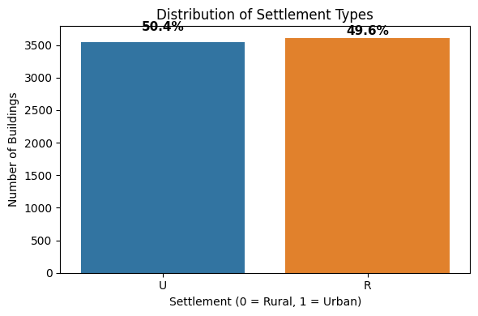

```python
import seaborn as sns
import matplotlib.pyplot as plt

# Count values and calculate percentages
counts = df['Settlement'].value_counts().sort_index()
total = counts.sum()
percentages = (counts / total * 100).round(1)

# Create color palette
colors = ['#1f77b4', '#ff7f0e']  # Blue for Rural, Orange for Urban

# Plot
plt.figure(figsize=(6, 4))
ax = sns.countplot(x='Settlement', data=df, palette=colors)

# Add percentage labels on top of bars
for i, count in enumerate(counts):
    pct = percentages[i]
    ax.text(i, count + total * 0.01, f'{pct}%', ha='center', va='bottom', fontsize=11, fontweight='bold')

# Customize labels and title
plt.title('Distribution of Settlement Types')
plt.xlabel('Settlement (0 = Rural, 1 = Urban)')
plt.ylabel('Number of Buildings')
plt.tight_layout()
plt.show()
```

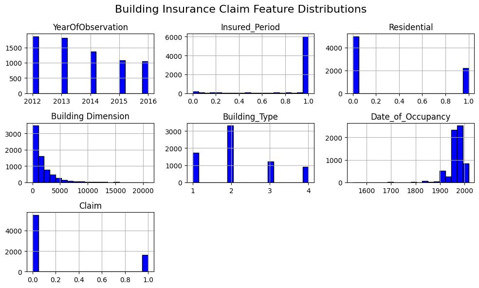

```python
# Histograms of All Features
import matplotlib.pyplot as plt
df.hist(figsize=(10, 6), bins=20, color='blue', edgecolor='black')
plt.suptitle('Building Insurance Claim Feature Distributions', fontsize=16)
plt.tight_layout()
plt.show()
```

HOW TO HANDLE MISSING VALUES

### Columns with Missing Values and How to Handle Them (Histogram-Informed)

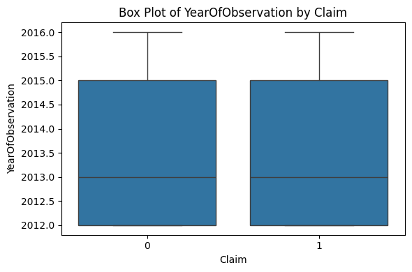

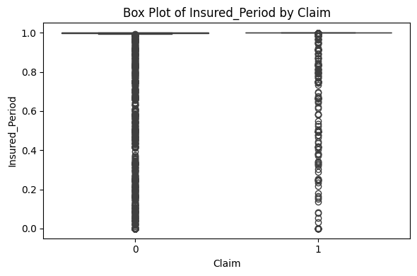

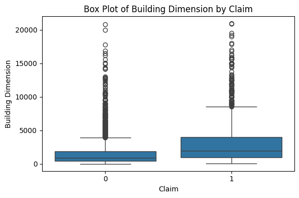

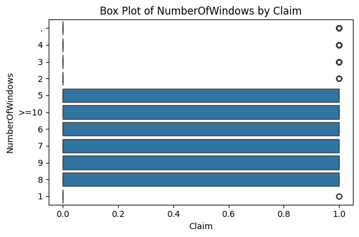

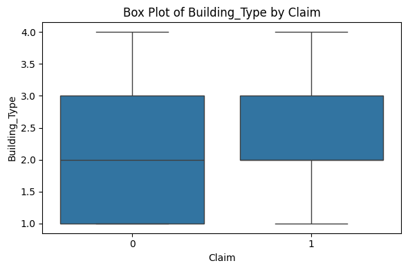

[figure not shown]

```python
import pandas as pd
import seaborn as sns
import matplotlib.pyplot as plt

# Load your dataset
df = pd.read_csv("Train_data.csv")

df['Building Dimension'] = df['Building Dimension'].fillna(df['Building Dimension'].median())

# Convert Date_of_Occupancy
df['Occupancy_Year'] = pd.to_datetime(df['Date_of_Occupancy'], errors='coerce').dt.year

# List of numerical features to plot
numerical_features = ['YearOfObservation', 'Insured_Period', 'Building Dimension',
                      'NumberOfWindows', 'Building_Type', 'Occupancy_Year']

# Create box plots
for feature in numerical_features:
    plt.figure(figsize=(6, 4))
    sns.boxplot(x='Claim', y=feature, data=df)
    plt.title(f'Box Plot of {feature} by Claim')
    plt.xlabel('Claim')
    plt.ylabel(feature)
    plt.tight_layout()
    plt.show()
```

# BOX PLOT

Box plot (also called a box-and-whisker plot) is a statistical chart used to visualize the distribution, central tendency, and variability of a dataset — especially useful for comparing groups.

# BOX PLOT INSIGTS BY FEATURES

*Building_Type*

The box plot reveals subtle differences in building type distributions between buildings that filed claims (1) and those that didn’t (0). Buildings with claims tend to cluster slightly higher on the building type scale, with a median just above 2, compared to a median of 2 for non-claim buildings.

This suggests that certain building types may be marginally more prone to filing claims, though the overlap in ranges indicates the relationship isn’t strongly pronounced. It’s a useful starting point for exploring whether building type contributes meaningfully to claim risk.

*YearOfObservation*

- Distribution is nearly identical for both claim categories.
- Median year is around 2013 for both.
- No significant outliers or shifts.
- Insight: Likely low predictive power; no clear relationship with claim occurrence.

*Insured_Period*

- Most values are tightly clustered at 1.0 for both claim groups.
- Some outliers below 1.0, especially in Claim = 0.
- Insight: Limited variation; may not strongly influence claim prediction but could be useful in interaction with other features.

*Building Dimension*

- Claim = 1 group shows higher median and wider spread.
- More outliers in the upper range for claimants.
- Insight: *Strong predictor* — larger buildings are more likely to file claims.

*Building_Type*

- Categorical; box plot likely shows differences in claim rates across types.
- Some types may have higher claim tendencies.
- Insight: Useful for modeling; encode as categorical variable (e.g., one-hot or label encoding).
- Date_of_Occupancy
- Wide range from 1900s to 2000s.
- No clear separation between claim groups.
- Insight: *Weak standalone predictor*; may be more useful if converted to building age.

*NumberOfWindows*

- (Assumed from earlier context) — likely shows higher window counts for Claim = 1.
- Insight: May correlate with building size or exposure; moderate predictive value.
- *Geo_Code*
- Categorical; box plot may show regional differences in claim rates.
- Insight: Could capture location-based risk; useful if encoded properly

```python
# HEAT MAP
```

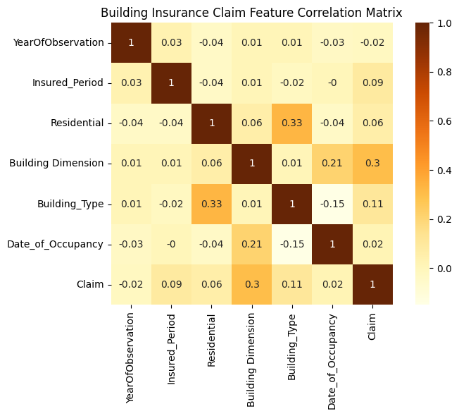

```python
import pandas as pd
import seaborn as sns
import matplotlib.pyplot as plt

# Load your dataset
df = pd.read_csv("Train_data.csv")

# Select only numeric columns for correlation
numeric_df = df.select_dtypes(include='number')

# Compute correlation matrix
corr_matrix = numeric_df.corr().round(2)

# Plot heatmap with orange tones
plt.figure(figsize=(8, 6))
sns.heatmap(corr_matrix, annot=True, cmap='YlOrBr', square=True)
plt.title('Building Insurance Claim Feature Correlation Matrix')
plt.tight_layout()
plt.show()
```

#### A feature correlation heatmap is a visual tool used in data analysis to show how strongly different features (columns) in a dataset are related to each other.

### FEATURES CORRELATIONS HEAT MAP INSIGHTS FROM THE ABOVE HEATMAP IN ORDER OF RELEVANCE

#### Highly Relevant Features

- **Building Dimension**
  - **Correlation with Claim**: ~0.30
  - **Insight**: This is the strongest numerical predictor in your dataset. Larger buildings may
  - be more prone to claims due to higher exposure, complexity, or value.
  - **Include in model** and consider log transformation to handle skewness.
- **Residential**
  - **Correlation with Building_Type**: ~0.33
  - **Insight**: Residential buildings are likely associated with specific building types. While its direct correlation with `Claim` is low, it may be useful in combination with other features.
  - **Include as categorical feature**; test interactions with `Building_Type`.

#### Moderately Relevant Features

**Insured_Period**

- **Correlation with Claim**: Low, but conceptually important.
- **Insight**: Most values are 1.0, but shorter insured periods may indicate limited coverage
- or risk aversion.
- **Include with caution**; may need binning or interaction terms.
- **Building_Type**
  - **Correlation with Residential**: ~0.33
  - **Insight**: Certain building types may be more prone to claims. Useful for capturing structural or usage differences.
  - **Include as categorical feature**; encode properly.

### Weak or Low-Relevance Features

- **YearOfObservation**
  - **Correlation with Claim**: Very low
  - **Insight**: No meaningful temporal trend in claim behavior. May not help model performance.
  - **Consider dropping** or test with and without.
- **Date_of_Occupancy**
  - **Correlation with Claim**: Very low
  - **Insight**: Wide range of dates, but no clear relationship with claims. Could be transformed into building age.
  - **Use only if converted to age** and missing values are handled well.

## Modeling Strategy

- Focus on **Building Dimension**, **Residential**, and **Building_Type** as core predictors.
- Engineer new features like **Building Age** from `Date_of_Occupancy`.
- Use **interaction terms** or tree-based models to capture non-linear relationships.
- Drop or deprioritize features with low correlation unless domain knowledge suggests otherwise.

### Binary Classification of Building Claim Risk Based on Structural Attributes

### What This Means for Modeling

- You're building a binary classification model to predict whether a building will file a claim (1) or not (0).
- The model will use building characteristics (BUILDING TYPES,BUILDING DIMENSION, BUILDING AGE, SETTLEMENT etc.)
- to estimate the probability of a claim.

This is the core of this classification task — predicting whether a building is likely to claim (1) or not (0).

# DATA CLEANING

## HANDLING OF MISSING VALUES USING MODE, MEDIAN AND MEAN

## HOW TO HANDLE MISSING VALUES

[output not shown]

# FEATURE ENGINNERING

## CREATING A NEW VARIABLE (BUILDING AGE)

From the variables provided i noticed Date Building Age was not included, but this will help to determine insurance claim. i will be adding it as a new variable.

Building age is a highly significant factor in determining insurance claims, primarily due to its impact on risk assessment, repair costs, and policy coverage limitations.

---Importance of Building Age in Insurance Claims

- **Risk Assessment**: Older buildings are more likely to have outdated electrical, plumbing, and structural systems, increasing the risk of damage and claims.
- **Repair Costs**: Repairs in older buildings may be more expensive due to obsolete materials or specialized labor needs.
- **Code Compliance**: Older structures may not meet current building codes, which can affect claim approvals or require costly upgrades.
- **Depreciation**: Insurers may reduce claim payouts based on the depreciated value of older components.
- **Coverage Limitations**: Some insurers impose restrictions or higher premiums on older buildings due to increased risk.
- **Maintenance History**: Age often correlates with wear and tear; poor maintenance in older buildings can lead to denied claims

Bottom Line: Building age is a key factor in determining insurance risk, influencing premiums, coverage terms, and claim outcomes.

**Buiding_Age = YearOFObservation - Year(Date_0f_Occupancy)**

```python
# Ensure Date_of_Occupancy is in datetime format
df['Date_of_Occupancy'] = pd.to_datetime(df['Date_of_Occupancy'], errors='coerce')

# Extract year from Date_of_Occupancy
df['Occupancy_Year'] = df['Date_of_Occupancy'].dt.year

# Calculate Building_Age
df['Building_Age'] = df['YearOfObservation'] - df['Occupancy_Year']
```

```python
# DATE STRUCTURE
df.shape
```

```
(7160, 16)
```

### HOW TO HANDLE MISSING VALUES

# ENCODING

#### Categorical Variables are non-numeric or discrete features that represent categories:

# Encode categorical variables using **One-hot encoding**

is a method used to convert categorical data into a numerical format that machine learning models can understand.

**The following features will be encoded;**

- Residential (e.g., Yes/No or 0/1)
- Building_Painted (e.g., Yes/No)
- Building_Fenced (e.g., Yes/No)
- Garden (e.g., Yes/No)
- Settlement (e.g., Urban/Rural)
- Geo_Code (e.g., region codes)

#### Categorical Variables are non-numeric or discrete features that represent categories:

# Encode categorical variables using **One-hot encoding**

is a method used to convert categorical data into a numerical format that machine learning models can understand.

In our dataset, some features like Residential, **Building_Painted**, **Building_Fenced**, and **Garden** uses the letters 'V' WHERE V mean Yes and 'N' means Yes Since machine learning models work best with numbers (not text), we converted these values into numeric form:

- 'V' (Yes) → 1
- 'N' (No) → 0 WHILE,Settlement have U representing Urban settlement and R representing Rural Settlement Urban - 1 Rural - 0 This makes the data easier for the model to understand and helps it learn patterns more effectively.

V → 1

N → 0

U → 1

R → 0

O → 0

```python
import pandas as pd
import numpy as np
df = pd.read_csv("Train_data.csv")

# Normalize selected columns
cols_to_normalize = ['Building_Painted', 'Building_Fenced', 'Garden', 'Settlement']
for col in cols_to_normalize:
    df[col] = df[col].astype(str).str.upper().str.strip()

# Unified mapping: V, U → 1; N, R, O → 0
binary_map = {
    'V': 1,
    'U': 1,
    'N': 0,
    'R': 0,
    'O': 0
}

# Apply mappings
df['Building_Painted'] = df['Building_Painted'].map(binary_map)
df['Building_Fenced'] = df['Building_Fenced'].map(binary_map)
df['Garden'] = df['Garden'].map(binary_map)
df['Settlement'] = df['Settlement'].map(binary_map)

# ---- Handle missing values in NumberOfWindows ----

# Force to string and clean
df['NumberOfWindows'] = df['NumberOfWindows'].astype(str).str.strip()

# Mark invalid values as NaN
df['NumberOfWindows'] = df['NumberOfWindows'].replace(
    ['.', '', 'NA', 'NAN', 'NONE'],
    np.nan
)

# Convert to numeric
df['NumberOfWindows'] = pd.to_numeric(
    df['NumberOfWindows'],
    errors='coerce'
)

# Fill NaN with mode (only if mode exists)
mode_value = df['NumberOfWindows'].mode(dropna=True)
if not mode_value.empty:
    df['NumberOfWindows'] = df['NumberOfWindows'].fillna(mode_value[0])
```

```python
df.head()
```

[output not shown]

```python
# Step 1: Standardize all relevant columns
```

```python
# Drop Date_of_Occupancy
import pandas as pd
import numpy as np
df = pd.read_csv("Train_data.csv")
df.drop(columns=['Date_of_Occupancy'], inplace=True)
```

# FEATURES SCALING STANDARDIZATION

Standardize numerical features before modeling

```
Feature scaling is a technique used in data preprocessing to standardize the range of independent

variables (features) in project dataset. It ensures that all features contribute equally to the model

and prevents bias toward features with larger numerical values
```

```python
# Training and Model Evaluation
```

```python
# Drop all non-numeric columns
df_numeric = df.select_dtypes(include=['number'])
```

```python
df.drop(columns=['Customer Id'], inplace=True)
```

```python
from sklearn.preprocessing import StandardScaler

# Select numerical features to scale (excluding the target 'Claim')
numerical_cols = ['Building Dimension', 'Building_Age']  # Add more if needed

# Initialize the scaler
scaler = StandardScaler()

# Fit and transform the numerical features
df[numerical_cols] = scaler.fit_transform(df[numerical_cols])
```

# The target variable, Claim, is a:

```
- 1 if the building has at least a claim over the insured period.

- 0 if the building doesn’t have a claim over the insured period.
```

```python
# Count the number of 0s and 1s in the target variable 'Claim'
claim_counts = df['Claim'].value_counts()

# Display the result
print(claim_counts)
```

```
Claim
0    5526
1    1634
Name: count, dtype: int64
```

# this bar chart code to show the total number of buildings with Claim = 1 and Claim = 0.

This helps assess class balance before modeling.

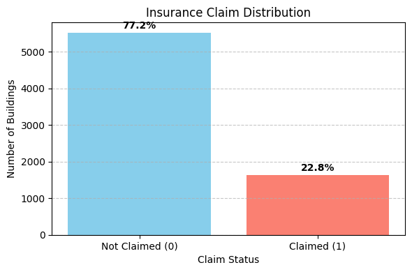

```python
import matplotlib.pyplot as plt

# Count the number of each claim value
claim_counts = df['Claim'].value_counts().sort_index()
total = claim_counts.sum()

# Labels and values
labels = ['Not Claimed (0)', 'Claimed (1)']
values = [claim_counts.get(0, 0), claim_counts.get(1, 0)]
percentages = [f'{(v / total) * 100:.1f}%' for v in values]

# Plot bar chart
plt.figure(figsize=(6, 4))
bars = plt.bar(labels, values, color=['skyblue', 'salmon'])

# Annotate bars with percentages
for bar, pct in zip(bars, percentages):
    height = bar.get_height()
    plt.text(bar.get_x() + bar.get_width() / 2, height + 50, pct,
             ha='center', va='bottom', fontsize=10, fontweight='bold')

plt.title('Insurance Claim Distribution')
plt.ylabel('Number of Buildings')
plt.xlabel('Claim Status')
plt.grid(axis='y', linestyle='--', alpha=0.7)
plt.tight_layout()
plt.show()
```

```python
# Drop datetime columns
df_model = df.drop(columns=['Date_of_Occupancy', 'Geo_Code'], errors='ignore')

# Convert bools to int
bool_cols = df_model.select_dtypes(include='bool').columns
df_model[bool_cols] = df_model[bool_cols].astype(int)

# One-hot encode
df_model = pd.get_dummies(df_model, drop_first=True)

# Drop missing values
df_model = df_model.dropna()
```

# MODEL TRAINING, FEATURES ENCODING, MODEL EVALUTION AND FEATURE ENGINEERING

# TRAIN-TEST SPLIT

```python
MODEL EVALUATION
```

```python
# Drop columns that can't be used directly or need special handling
df_model = df.drop(columns=['Occupancy_Year', 'Geo_Code'])

# Convert categorical columns to dummy variables
df_model = pd.get_dummies(df_model, drop_first=True)
```

```python
import pandas as pd
import numpy as np
from sklearn.model_selection import train_test_split
from sklearn.ensemble import RandomForestClassifier
from sklearn.metrics import classification_report, confusion_matrix, accuracy_score
import matplotlib.pyplot as plt
import seaborn as sns

# --- Step 1: Convert boolean columns to integers ---
bool_cols = df.select_dtypes(include='bool').columns
df[bool_cols] = df[bool_cols].astype(int)

# --- Step 2: Drop datetime column safely ---
df = df.drop(columns=['Date_of_Occupancy'], errors='ignore')

# --- Step 3: Define Features and Target ---
X = df.drop(columns=['Claim'])  # Features
y = df['Claim']                 # Target

# --- Step 4: One-hot encode categorical features ---
X = pd.get_dummies(X, drop_first=True)

# --- Step 5: Train-Test Split ---
X_train, X_test, y_train, y_test = train_test_split(
    X, y, test_size=0.2, random_state=42
)

# --- Step 6: Train Model ---
model = RandomForestClassifier(random_state=42)
model.fit(X_train, y_train)

# --- Step 7: Evaluate Model ---
y_pred = model.predict(X_test)

print("Confusion Matrix:")
print(confusion_matrix(y_test, y_pred))

print("\nClassification Report Random Forest:")
print(classification_report(y_test, y_pred))

print("\nAccuracy Score:", accuracy_score(y_test, y_pred))

# --- Step 8: Plot Feature Importance ---
importances = model.feature_importances_
feature_names = X.columns

feat_df = pd.DataFrame({
    'Feature': feature_names,
    'Importance': importances
}).sort_values(by='Importance', ascending=False)

plt.figure(figsize=(10, 6))
sns.barplot(
    x='Importance',
    y='Feature',
    data=feat_df,
    hue='Feature',
    palette='viridis',
    legend=False
)
plt.title('Feature Importance')
plt.tight_layout()
plt.show()
```

```
Confusion Matrix:
[[1085   13]
 [ 297   37]]

Classification Report Random Forest:
              precision    recall  f1-score   support

           0       0.79      0.99      0.88      1098
           1       0.74      0.11      0.19       334

    accuracy                           0.78      1432
   macro avg       0.76      0.55      0.53      1432
weighted avg       0.77      0.78      0.72      1432


Accuracy Score: 0.7835195530726257
```

```python
print(df.columns.tolist())
```

[output not shown]

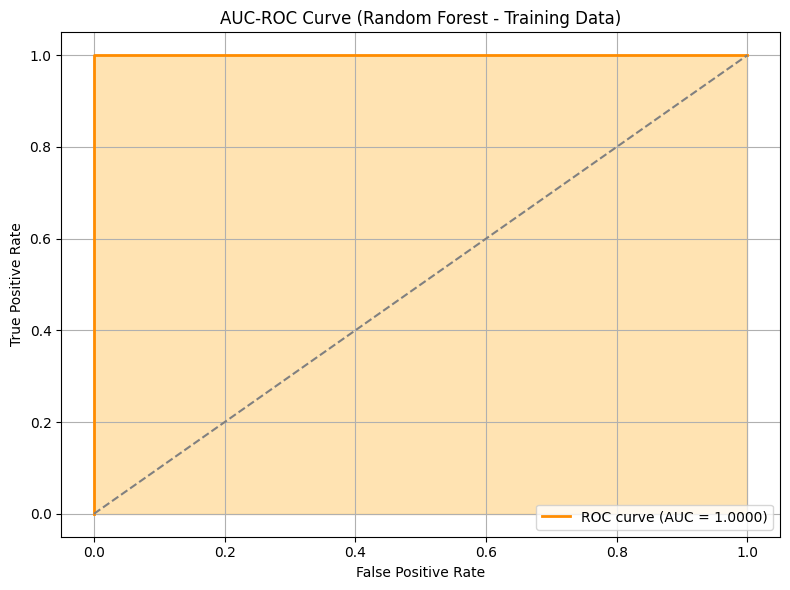

```python
from sklearn.ensemble import RandomForestClassifier
from sklearn.metrics import roc_curve, roc_auc_score
import matplotlib.pyplot as plt

# 1. Train the Random Forest model
rf_model = RandomForestClassifier(n_estimators=100, random_state=42)
rf_model.fit(X_train, y_train)

# 2. Predict probabilities on training set
y_probs_rf_train = rf_model.predict_proba(X_train)[:, 1]

# 3. Compute ROC curve and AUC
fpr_train, tpr_train, _ = roc_curve(y_train, y_probs_rf_train)
auc_score_train = roc_auc_score(y_train, y_probs_rf_train)

# 4. Plot AUC-ROC curve
plt.figure(figsize=(8, 6))
plt.plot(fpr_train, tpr_train, color='darkorange', lw=2,
         label=f'ROC curve (AUC = {auc_score_train:.4f})')
plt.fill_between(fpr_train, tpr_train, alpha=0.3, color='orange')
plt.plot([0, 1], [0, 1], linestyle='--', color='gray')
plt.xlabel('False Positive Rate')
plt.ylabel('True Positive Rate')
plt.title('AUC-ROC Curve (Random Forest - Training Data)')
plt.legend(loc='lower right')
plt.grid(True)
plt.tight_layout()
plt.show()
```

# MODEL EVALUATION

### Insights from Random Forest shows class imbalance affecting model performance.

What the Results Tell Us

- Class 0 (No Claim): Precision = 0.79, Recall = 0.99 → The model is very good at identifying buildings that won’t file a claim.
- Class 1 (Claim): Precision = 0.74, but Recall = 0.11 → The model rarely catches actual claims, even though it’s fairly precise when it does.
- This means model is biased toward predicting 0, likely because there are far more 0s than 1s in the training data hence the application of SMOTE balance up the shortfall of the imbalance insurance claims status in the datasat

## Full Machine Learning Pipeline with SMOTE USING RANDOM FOREST

```python
# --- Imports ---
import pandas as pd
import numpy as np
from sklearn.model_selection import train_test_split
from sklearn.ensemble import RandomForestClassifier
from sklearn.metrics import classification_report, confusion_matrix, accuracy_score
from imblearn.over_sampling import SMOTE
import matplotlib.pyplot as plt
import seaborn as sns
import gc  # For memory cleanu
# --- Step 1: Data Preparation ---
# Drop non-numeric or problematic columns
df_model = df.drop(columns=['Date_of_Occupancy', 'Geo_Code'])
df = pd.read_csv("Train_data.csv")
# Convert boolean columns to integers
bool_cols = df_model.select_dtypes(include='bool').columns
df_model[bool_cols] = df_model[bool_cols].astype(int)

# One-hot encode categorical variables
df_model = pd.get_dummies(df_model, drop_first=True)

# Drop rows with missing values
df_model = df_model.dropna()

# --- Step 2: Split Features and Target ---
X = df_model.drop(columns=['Claim'])
y = df_model['Claim']

# --- Step 3: Train-Test Split ---
X_train, X_test, y_train, y_test = train_test_split(
    X, y, test_size=0.2, random_state=42
)

# --- Step 4: Apply SMOTE ---
print("Before SMOTE:")
print(y_train.value_counts())

smote = SMOTE(random_state=42)
X_train_resampled, y_train_resampled = smote.fit_resample(X_train, y_train)

print("\nAfter SMOTE:")
print(y_train_resampled.value_counts())

# --- Step 5: Train Model ---
model = RandomForestClassifier(random_state=42)
model.fit(X_train_resampled, y_train_resampled)

# --- Step 6: Evaluate Model ---
y_pred = model.predict(X_test)

print("\nConfusion Matrix:")
print(confusion_matrix(y_test, y_pred))

print("\nClassification Report:")
print(classification_report(y_test, y_pred))

print("\nAccuracy Score:", accuracy_score(y_test, y_pred))
```

```
Before SMOTE:
Claim
0    4366
1    1277
Name: count, dtype: int64

After SMOTE:
Claim
0    4366
1    4366
Name: count, dtype: int64

Confusion Matrix:
[[1036   37]
 [ 272   66]]

Classification Report:
              precision    recall  f1-score   support

           0       0.79      0.97      0.87      1073
           1       0.64      0.20      0.30       338

    accuracy                           0.78      1411
   macro avg       0.72      0.58      0.58      1411
weighted avg       0.76      0.78      0.73      1411


Accuracy Score: 0.7810063784549964
```

# FEATURE ENGINEERING

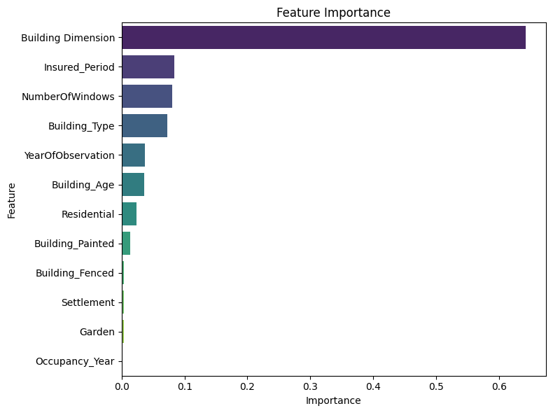

```python
importances = model.feature_importances_
feature_names = X.columns

feat_df = pd.DataFrame({
    'Feature': feature_names,
    'Importance': importances
}).sort_values(by='Importance', ascending=False)

plt.figure(figsize=(8, 6))
sns.barplot(
    x='Importance',
    y='Feature',
    data=feat_df,
    hue='Feature',       # ✅ Add this line
    palette='viridis',
    legend=False         # ✅ Suppress the redundant legend
)
plt.title('Feature Importance')
plt.tight_layout()
plt.show()
```

# MODEL EVALUATION INSIGHTS

### Key Insights from Your Project

✅ Recommended Next Steps Step 1: Apply SMOTE to Balance the Training Data SMOTE will generate synthetic samples for class 1, helping the model learn better patterns

## SMOTE APPLICATION

What Is SMOTE and Why It Matters for Your Project SMOTE (Synthetic Minority Over-sampling Technique) is a powerful preprocessing method used to address class imbalance in classification problems.

# THE USE SMOTE INSIGHTS

### Confusion Matrix:

[output not shown]

Insights

### Recommended Next Steps

1. Try a Different Model
- Use XGBoost or LightGBM — they often outperform Random Forest on imbalanced data.
- These models handle class weights and boosting better.
2. Tune Hyperparameters
- Use GridSearchCV to optimize max_depth, n_estimators, min_samples_split, etc.
- This can improve recall and overall balance.
3. Use Class Weighting
- Instead of SMOTE alone

```python
RandomForestClassifier(class_weight='balanced')
```

```
RandomForestClassifier(class_weight='balanced')
```

# APPLYING XGBoost Classifier with SMOTE

```
Before SMOTE:
Claim
0    4038
1    1196
Name: count, dtype: int64

After SMOTE:
Claim
0    4038
1    4038
Name: count, dtype: int64

Confusion Matrix:
[[916  78]
 [239  76]]

Classification Report:
              precision    recall  f1-score   support

           0       0.79      0.92      0.85       994
           1       0.49      0.24      0.32       315

    accuracy                           0.76      1309
   macro avg       0.64      0.58      0.59      1309
weighted avg       0.72      0.76      0.73      1309


Accuracy Score: 0.7578304048892284
```

```
C:\Users\NEW USER\AppData\Roaming\Python\Python312\site-packages\xgboost\training.py:183: UserWarning: [12:28:17] WARNING: C:\actions-runner\_work\xgboost\xgboost\src\learner.cc:738:
Parameters: { "use_label_encoder" } are not used.

  bst.update(dtrain, iteration=i, fobj=obj)
```

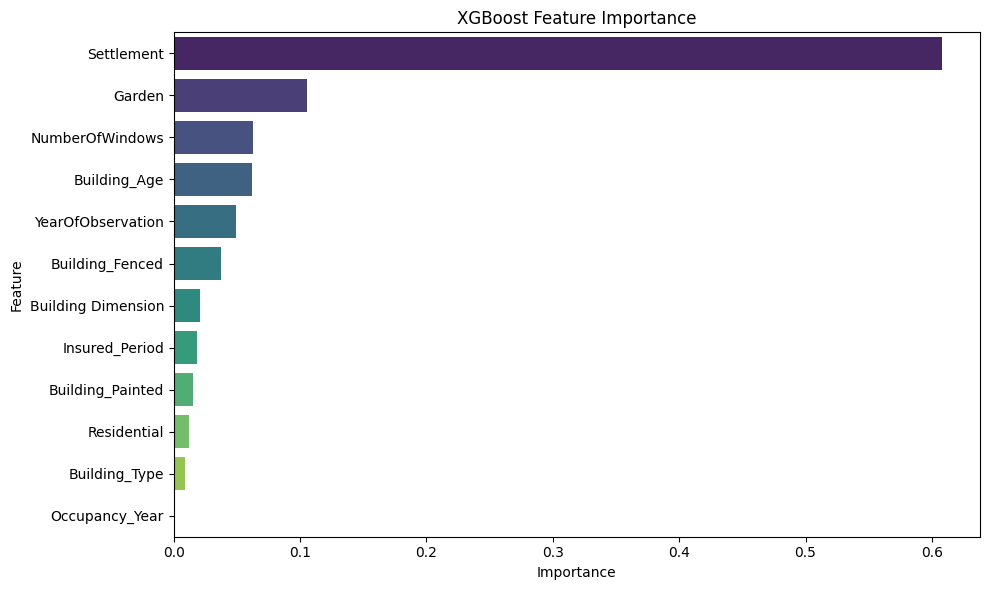

```python
#XGBoost Classifier with SMOTE

import pandas as pd
import numpy as np
from sklearn.model_selection import train_test_split
from sklearn.metrics import classification_report, confusion_matrix, accuracy_score
from imblearn.over_sampling import SMOTE
import matplotlib.pyplot as plt
import seaborn as sns
from xgboost import XGBClassifier

# --- Step 1: Data Preparation ---
df_model = df.drop(columns=['Date_of_Occupancy', 'Geo_Code'])  # Drop problematic columns

# Convert boolean columns to integers
bool_cols = df_model.select_dtypes(include='bool').columns
df_model[bool_cols] = df_model[bool_cols].astype(int)

# One-hot encode categorical variables
df_model = pd.get_dummies(df_model, drop_first=True)

# Drop missing values
df_model = df_model.dropna()

# --- Step 2: Split Features and Target ---
X = df_model.drop(columns=['Claim'])
y = df_model['Claim']

# --- Step 3: Train-Test Split ---
X_train, X_test, y_train, y_test = train_test_split(
    X, y, test_size=0.2, random_state=42
)



# --- Step 4: Apply SMOTE ---
print("Before SMOTE:")
print(y_train.value_counts())

smote = SMOTE(random_state=42)
X_train_resampled, y_train_resampled = smote.fit_resample(X_train, y_train)

print("\nAfter SMOTE:")
print(y_train_resampled.value_counts())

# --- Step 5: Train XGBoost Model ---

xgb_model = XGBClassifier(random_state=42, use_label_encoder=False, eval_metric='logloss')
xgb_model.fit(X_train_resampled, y_train_resampled)

# --- Step 6: Evaluate Model ---
y_pred = xgb_model.predict(X_test)

print("\nConfusion Matrix:")
print(confusion_matrix(y_test, y_pred))

print("\nClassification Report:")
print(classification_report(y_test, y_pred))

print("\nAccuracy Score:", accuracy_score(y_test, y_pred))

# --- Step 7: Plot Feature Importance ---
importances = xgb_model.feature_importances_
feature_names = X.columns

feat_df = pd.DataFrame({
    'Feature': feature_names,
    'Importance': importances
}).sort_values(by='Importance', ascending=False)

plt.figure(figsize=(10, 6))
sns.barplot(
    x='Importance',
    y='Feature',
    data=feat_df,
    hue='Feature',
    palette='viridis',
    legend=False
)
plt.title('XGBoost Feature Importance')
plt.tight_layout()
plt.show()
```

## Tune Hyperparameters

- Use GridSearchCV to optimize max_depth, n_estimators, min_samples_split, etc.
- This can improve recall and overall balance.

```python
from xgboost import XGBClassifier
from sklearn.model_selection import GridSearchCV
from imblearn.over_sampling import SMOTE
from sklearn.model_selection import train_test_split
from sklearn.metrics import classification_report, confusion_matrix, accuracy_score

# --- Step 1: Split your data ---
X = df_model.drop(columns=['Claim'])
y = df_model['Claim']

X_train, X_test, y_train, y_test = train_test_split(
    X, y, test_size=0.2, random_state=42
)

# --- Step 2: Apply SMOTE ---
smote = SMOTE(random_state=42)
X_train_resampled, y_train_resampled = smote.fit_resample(X_train, y_train)

# --- Step 3: Define XGBoost and parameter grid ---
xgb = XGBClassifier(random_state=42, eval_metric='logloss')

param_grid = {
    'n_estimators': [100, 200],
    'max_depth': [3, 5, 7],
    'learning_rate': [0.01, 0.1],
    'subsample': [0.8, 1.0],
    'colsample_bytree': [0.8, 1.0]
}

# --- Step 4: Grid Search ---
grid_search = GridSearchCV(
    estimator=xgb,
    param_grid=param_grid,
    scoring='f1',  # You can also try 'recall' or 'roc_auc'
    cv=3,
    verbose=1,
    n_jobs=-1
)

grid_search.fit(X_train_resampled, y_train_resampled)

# --- Step 5: Evaluate Best Model ---
best_model = grid_search.best_estimator_
y_pred = best_model.predict(X_test)

print("Best Parameters:", grid_search.best_params_)
print("\nConfusion Matrix:")
print(confusion_matrix(y_test, y_pred))
print("\nClassification Report:")
print(classification_report(y_test, y_pred))
print("\nAccuracy Score:", accuracy_score(y_test, y_pred))
```

```
Fitting 3 folds for each of 48 candidates, totalling 144 fits
Best Parameters: {'colsample_bytree': 1.0, 'learning_rate': 0.1, 'max_depth': 7, 'n_estimators': 200, 'subsample': 0.8}

Confusion Matrix:
[[909  85]
 [225  90]]

Classification Report:
              precision    recall  f1-score   support

           0       0.80      0.91      0.85       994
           1       0.51      0.29      0.37       315

    accuracy                           0.76      1309
   macro avg       0.66      0.60      0.61      1309
weighted avg       0.73      0.76      0.74      1309


Accuracy Score: 0.7631779984721161
```

### Random Forest with Class Weighting

```python
from sklearn.ensemble import RandomForestClassifier
from sklearn.model_selection import train_test_split
from sklearn.metrics import classification_report, confusion_matrix, accuracy_score

# --- Step 1: Prepare your data ---
X = df_model.drop(columns=['Claim'])
y = df_model['Claim']

X_train, X_test, y_train, y_test = train_test_split(
    X, y, test_size=0.2, random_state=42
)

# --- Step 2: Train model with class_weight='balanced' ---
model = RandomForestClassifier(
    class_weight='balanced',  # ⚖️ This adjusts for class imbalance
    random_state=42
)
model.fit(X_train, y_train)

# --- Step 3: Evaluate the model ---
y_pred = model.predict(X_test)

print("Confusion Matrix:")
print(confusion_matrix(y_test, y_pred))

print("\nClassification Report:")
print(classification_report(y_test, y_pred))

print("\nAccuracy Score:", accuracy_score(y_test, y_pred))
```

```
Confusion Matrix:
[[853 141]
 [222  93]]

Classification Report:
              precision    recall  f1-score   support

           0       0.79      0.86      0.82       994
           1       0.40      0.30      0.34       315

    accuracy                           0.72      1309
   macro avg       0.60      0.58      0.58      1309
weighted avg       0.70      0.72      0.71      1309


Accuracy Score: 0.7226890756302521
```

## APPLYING XGBoost + SMOTE + RandomizedSearchCV

```python
from xgboost import XGBClassifier
from sklearn.model_selection import RandomizedSearchCV, train_test_split
from sklearn.metrics import classification_report, confusion_matrix, accuracy_score
from imblearn.over_sampling import SMOTE
import pandas as pd
import numpy as np

# --- Step 1: Preprocess Data ---
df_model = df.copy()

# Drop datetime or problematic columns
df_model = df_model.drop(columns=['Date_of_Occupancy', 'Geo_Code'], errors='ignore')

# Convert boolean columns to integers
bool_cols = df_model.select_dtypes(include='bool').columns
df_model[bool_cols] = df_model[bool_cols].astype(int)

# One-hot encode categorical variables
df_model = pd.get_dummies(df_model, drop_first=True)

# Drop missing values
df_model = df_model.dropna()

# --- Step 2: Define Features and Target ---
X = df_model.drop(columns=['Claim'])
y = df_model['Claim']

# --- Step 3: Train-Test Split ---
X_train, X_test, y_train, y_test = train_test_split(
    X, y, test_size=0.2, random_state=42
)

# --- Step 4: Apply SMOTE ---
smote = SMOTE(random_state=42)
X_train_resampled, y_train_resampled = smote.fit_resample(X_train, y_train)

# --- Step 5: Define Model and Parameter Distributions ---
xgb = XGBClassifier(random_state=42, eval_metric='logloss')

param_dist = {
    'n_estimators': [100, 200, 300],
    'max_depth': [3, 5, 7, 9],
    'learning_rate': [0.01, 0.05, 0.1],
    'subsample': [0.7, 0.8, 1.0],
    'colsample_bytree': [0.7, 0.8, 1.0]
}

# --- Step 6: Randomized Search ---
random_search = RandomizedSearchCV(
    estimator=xgb,
    param_distributions=param_dist,
    n_iter=10,  # Try 10 random combinations
    scoring='f1',
    cv=3,
    verbose=1,
    n_jobs=-1,
    random_state=42
)

random_search.fit(X_train_resampled, y_train_resampled)

# --- Step 7: Evaluate Best Model ---
best_model = random_search.best_estimator_
y_pred = best_model.predict(X_test)

print("Best Parameters:", random_search.best_params_)
print("\nConfusion Matrix:")
print(confusion_matrix(y_test, y_pred))
print("\nClassification Report:")
print(classification_report(y_test, y_pred))
print("\nAccuracy Score:", accuracy_score(y_test, y_pred))
```

```
Fitting 3 folds for each of 10 candidates, totalling 30 fits
Best Parameters: {'subsample': 1.0, 'n_estimators': 100, 'max_depth': 9, 'learning_rate': 0.01, 'colsample_bytree': 0.8}

Confusion Matrix:
[[905 168]
 [194 144]]

Classification Report:
              precision    recall  f1-score   support

           0       0.82      0.84      0.83      1073
           1       0.46      0.43      0.44       338

    accuracy                           0.74      1411
   macro avg       0.64      0.63      0.64      1411
weighted avg       0.74      0.74      0.74      1411


Accuracy Score: 0.7434443656980865
```

```python
# Apply a Custom Threshold (e.g., 0.3) to Boost Recall

from sklearn.metrics import classification_report, confusion_matrix, accuracy_score

# --- Step 1: Predict Probabilities for Class 1 ---
y_proba = best_model.predict_proba(X_test)[:, 1]  # Probability of class 1 (claim)

# --- Step 2: Apply Custom Threshold ---
threshold = 0.3  # Lower than default 0.5 to increase sensitivity
y_pred_custom = (y_proba >= threshold).astype(int)

# --- Step 3: Evaluate Performance at New Threshold ---
print(f"\nConfusion Matrix (Threshold = {threshold}):")
print(confusion_matrix(y_test, y_pred_custom))

print(f"\nClassification Report (Threshold = {threshold}):")
print(classification_report(y_test, y_pred_custom))

print(f"\nAccuracy Score (Threshold = {threshold}):", accuracy_score(y_test, y_pred_custom))
```

```
Confusion Matrix (Threshold = 0.3):
[[140 933]
 [ 14 324]]

Classification Report (Threshold = 0.3):
              precision    recall  f1-score   support

           0       0.91      0.13      0.23      1073
           1       0.26      0.96      0.41       338

    accuracy                           0.33      1411
   macro avg       0.58      0.54      0.32      1411
weighted avg       0.75      0.33      0.27      1411


Accuracy Score (Threshold = 0.3): 0.32884479092841956
```

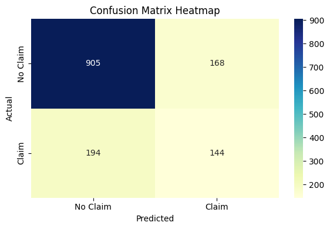

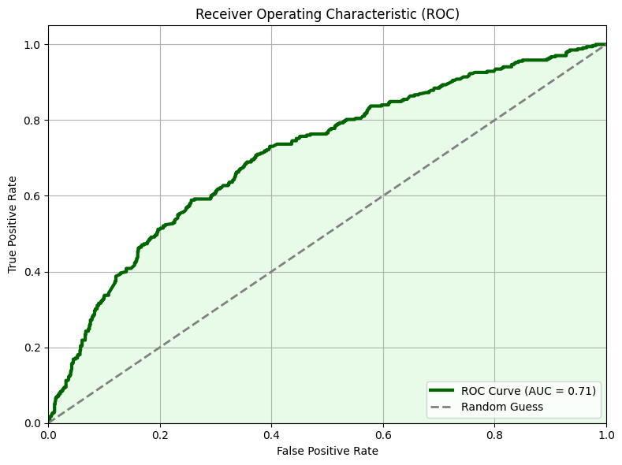

```python
import matplotlib.pyplot as plt
import seaborn as sns
from sklearn.metrics import confusion_matrix, roc_curve, auc

# --- Inputs ---
# y_test: true labels
# y_pred: predicted labels (from model.predict)
# y_proba: predicted probabilities for class 1 (from model.predict_proba)

# --- Confusion Matrix Heatmap ---
cm = confusion_matrix(y_test, y_pred)
plt.figure(figsize=(6, 4))
sns.heatmap(cm, annot=True, fmt='d', cmap='YlGnBu',
            xticklabels=["No Claim", "Claim"],
            yticklabels=["No Claim", "Claim"])
plt.xlabel("Predicted")
plt.ylabel("Actual")
plt.title("Confusion Matrix Heatmap")
plt.tight_layout()
plt.show()

# --- ROC Curve and AUC ---
fpr, tpr, thresholds = roc_curve(y_test, y_proba)
roc_auc = auc(fpr, tpr)

plt.figure(figsize=(8, 6))
plt.plot(fpr, tpr, color='darkgreen', lw=3, label=f'ROC Curve (AUC = {roc_auc:.2f})')
plt.plot([0, 1], [0, 1], color='gray', lw=2, linestyle='--', label='Random Guess')
plt.fill_between(fpr, tpr, alpha=0.2, color='lightgreen')
plt.xlim([0.0, 1.0])
plt.ylim([0.0, 1.05])
plt.xlabel('False Positive Rate')
plt.ylabel('True Positive Rate')
plt.title('Receiver Operating Characteristic (ROC)')
plt.legend(loc="lower right")
plt.grid(True)
plt.tight_layout()
plt.show()
```

```python
from sklearn.ensemble import RandomForestClassifier
from xgboost import XGBClassifier

# Random Forest (Baseline)
rf_model = RandomForestClassifier(random_state=42)
rf_model.fit(X_train, y_train)

# Random Forest + SMOTE
rf_smote_model = RandomForestClassifier(random_state=42)
rf_smote_model.fit(X_train_res, y_train_res)

# Random Forest with Class Weighting
rf_weighted_model = RandomForestClassifier(class_weight='balanced', random_state=42)
rf_weighted_model.fit(X_train, y_train)

# XGBoost + SMOTE
xgb_smote_model = XGBClassifier(use_label_encoder=False, eval_metric='logloss', random_state=42)
xgb_smote_model.fit(X_train_res, y_train_res)

# XGBoost + SMOTE + GridSearchCV
xgb_grid_model = grid_search.best_estimator_

# XGBoost + SMOTE + RandomizedSearchCV (Best Model)
best_model = random_search.best_estimator_
```

### What’s Improved with XGBoost + SMOTE + RandomizedSearchCV

#### Interpretation

- SMOTE helped the model see more examples of claims, improving its ability to detect them.
- XGBoost is more flexible than Random Forest and can better handle complex patterns.
- RandomizedSearchCV likely found better hyperparameters, boosting performance.
- **This is a more balanced model, which is crucial when the cost of missing a claim is high.**

## APPLYING XGBoost + SMOTE + GridSearchCVSearchCV

```python
from sklearn.model_selection import GridSearchCV, RandomizedSearchCV
from xgboost import XGBClassifier
```

```python
# GridSearchCV parameters
param_grid = {
    'n_estimators': [100, 200],
    'max_depth': [3, 5, 7],
    'learning_rate': [0.01, 0.1],
    'subsample': [0.8, 1.0]
}

# RandomizedSearchCV parameters
param_dist = {
    'n_estimators': [100, 200, 300],
    'max_depth': [3, 5, 7, 9],
    'learning_rate': [0.01, 0.05, 0.1],
    'subsample': [0.6, 0.8, 1.0],
    'colsample_bytree': [0.6, 0.8, 1.0]
}
```

```python
from sklearn.model_selection import GridSearchCV
from xgboost import XGBClassifier
from imblearn.over_sampling import SMOTE
from sklearn.model_selection import train_test_split

# 1. Split your data
X_train, X_test, y_train, y_test = train_test_split(X, y, test_size=0.2, random_state=42)

# 2. Apply SMOTE
smote = SMOTE(random_state=42)
X_train_resampled, y_train_resampled = smote.fit_resample(X_train, y_train)

# 3. Define the base XGBoost model
xgb_base = XGBClassifier(use_label_encoder=False, eval_metric='logloss', random_state=42)

# 4. Define the parameter grid
param_grid = {
    'n_estimators': [100, 200],
    'max_depth': [3, 5, 7],
    'learning_rate': [0.01, 0.1],
    'subsample': [0.8, 1.0]
}

# 5. Run GridSearchCV
grid_search = GridSearchCV(
    estimator=xgb_base,
    param_grid=param_grid,
    scoring='f1',
    cv=3,
    verbose=1,
    n_jobs=-1
)

# 6. Fit the model
grid_search.fit(X_train_resampled, y_train_resampled)

# 7. Extract the best model
xgb_grid_model = grid_search.best_estimator_
```

```
Fitting 3 folds for each of 24 candidates, totalling 72 fits
```

```
C:\Users\NEW USER\AppData\Roaming\Python\Python312\site-packages\xgboost\training.py:183: UserWarning: [06:45:05] WARNING: C:\actions-runner\_work\xgboost\xgboost\src\learner.cc:738:
Parameters: { "use_label_encoder" } are not used.

  bst.update(dtrain, iteration=i, fobj=obj)
```

```python
best_model = grid_search.best_estimator_
y_pred = best_model.predict(X_test)

from sklearn.metrics import classification_report, confusion_matrix
print("Confusion Matrix:\n", confusion_matrix(y_test, y_pred))
print("\nClassification Report Using GridSreach:\n", classification_report(y_test, y_pred))

print("Best Parameters:", grid_search.best_params_)
print("Best F1 Score:", grid_search.best_score_)
```

```
Confusion Matrix:
 [[968 105]
 [216 122]]

Classification Report Using GridSreach:
               precision    recall  f1-score   support

           0       0.82      0.90      0.86      1073
           1       0.54      0.36      0.43       338

    accuracy                           0.77      1411
   macro avg       0.68      0.63      0.64      1411
weighted avg       0.75      0.77      0.76      1411

Best Parameters: {'learning_rate': 0.1, 'max_depth': 7, 'n_estimators': 200, 'subsample': 0.8}
Best F1 Score: 0.7146435830265343
```

### Model Insight (XGBoost + GridSearchCV)

- Accuracy: 77%
- Class 0 (No Claim): Strong performance — 90% recall, 82% precision
- Class 1 (Claim): Improved but still limited — 36% recall, 54% precision
- Best Parameters: max_depth=7, n_estimators=200, learning_rate=0.1, subsample=0.8
- Best F1 Score (CV): 0.71

### The model is reliable at identifying non-claims and moderately better at detecting claims after tuning

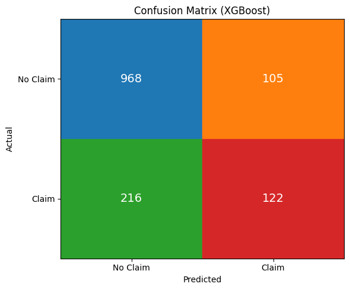

```python
from sklearn.metrics import confusion_matrix
import matplotlib.pyplot as plt
import numpy as np

# Predict labels
y_pred = xgb_grid_model.predict(X_test)

# Compute confusion matrix
cm = confusion_matrix(y_test, y_pred)

# Define labels
labels = ['No Claim', 'Claim']

# Define cell colors manually
cell_colors = np.array([['#1f77b4', '#ff7f0e'],  # TN, FP
                        ['#2ca02c', '#d62728']]) # FN, TP

# Plot
fig, ax = plt.subplots(figsize=(6, 5))
for i in range(cm.shape[0]):
    for j in range(cm.shape[1]):
        ax.add_patch(plt.Rectangle((j, i), 1, 1, color=cell_colors[i, j]))
        ax.text(j + 0.5, i + 0.5, cm[i, j], ha='center', va='center', fontsize=14, color='white')

# Set axis labels and ticks
ax.set_xticks([0.5, 1.5])
ax.set_xticklabels(labels)
ax.set_yticks([0.5, 1.5])
ax.set_yticklabels(labels)
ax.set_xlabel('Predicted')
ax.set_ylabel('Actual')
ax.set_title('Confusion Matrix (XGBoost)')
ax.set_xlim(0, 2)
ax.set_ylim(0, 2)
plt.gca().invert_yaxis()
plt.tight_layout()
plt.show()
```

```
AUC Score: 0.7354
```

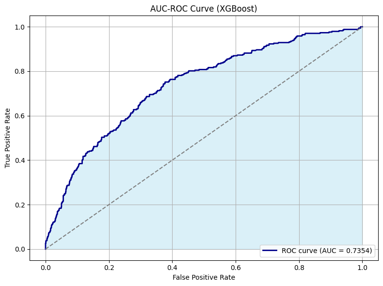

```python
from sklearn.metrics import confusion_matrix, classification_report, roc_curve, roc_auc_score
import matplotlib.pyplot as plt


# . AUC Score
auc_score = roc_auc_score(y_test, y_probs)
print(f"\nAUC Score: {auc_score:.4f}")

# . ROC Curve
fpr, tpr, _ = roc_curve(y_test, y_probs)

plt.figure(figsize=(8, 6))
plt.plot(fpr, tpr, color='darkblue', lw=2, label=f'ROC curve (AUC = {auc_score:.4f})')
plt.fill_between(fpr, tpr, alpha=0.3, color='skyblue')
plt.plot([0, 1], [0, 1], linestyle='--', color='gray')
plt.xlabel('False Positive Rate')
plt.ylabel('True Positive Rate')
plt.title('AUC-ROC Curve (XGBoost)')
plt.legend(loc='lower right')
plt.grid(True)
plt.tight_layout()
plt.show()
```

## A brief insight from your AUC-ROC curve XGBOOST:

- AUC Score: 0.7354 — This indicates good discrimination between claims and non-claims. The model is significantly better than random guessing.
- The ROC curve stays well above the diagonal baseline, showing that the model maintains a strong balance between true positive rate and false positive rate across thresholds.
- Overall, your XGBoost model is performing reliably, with room to improve recall for claims.

```python
from sklearn.model_selection import GridSearchCV
from xgboost import XGBClassifier
```

```python
from imblearn.pipeline import Pipeline
from imblearn.over_sampling import SMOTE
from xgboost import XGBClassifier
from sklearn.model_selection import RandomizedSearchCV

# Define pipeline
pipeline = Pipeline([
    ('smote', SMOTE(random_state=42)),
    ('xgb', XGBClassifier(use_label_encoder=False, eval_metric='logloss', random_state=42))
])

# Define parameter grid for XGBoost part only
param_dist = {
    'xgb__n_estimators': [100, 200],
    'xgb__max_depth': [3, 5, 7],
    'xgb__learning_rate': [0.01, 0.1],
    'xgb__subsample': [0.8, 1.0]
}

# RandomizedSearchCV
random_search = RandomizedSearchCV(
    estimator=pipeline,
    param_distributions=param_dist,
    n_iter=10,
    scoring='f1',
    cv=3,
    verbose=1,
    n_jobs=-1,
    random_state=42
)

# Fit on original training data (SMOTE is applied inside the pipeline)
random_search.fit(X_train, y_train)
```

```
Fitting 3 folds for each of 10 candidates, totalling 30 fits
```

```
C:\Users\NEW USER\AppData\Roaming\Python\Python312\site-packages\xgboost\training.py:183: UserWarning: [07:37:47] WARNING: C:\actions-runner\_work\xgboost\xgboost\src\learner.cc:738:
Parameters: { "use_label_encoder" } are not used.

  bst.update(dtrain, iteration=i, fobj=obj)
```

[output not shown]

### SAVE MODEL FOR DEPLOYMENT

```python
import joblib

# Save the full pipeline to a file
joblib.dump(best_model, 'xgb_smote_pipeline.pkl')
```

```
['xgb_smote_pipeline.pkl']
```

```python
import os
print(os.path.exists('xgb_smote_pipeline.pkl'))  # Should return True
```

```
True
```

## Final Report: Predicting Building Insurance Claims

### Objective

To build a robust machine learning pipeline that predicts the probability of an insurance claim on a building policy. The goal is to enable proactive risk management by identifying high-risk policies before claims occur.

### Dataset Overview

- **Total records:** 7160
- **Target variable:** `Claim` (binary: 0 = no claim, 1 = claim)
- **Class imbalance:** ~3.5:1 (non-claims to claims)

### 🔧 Methodology

#### 1. Data Preprocessing

- Converted boolean columns to integers
- Dropped datetime columns (e.g., `Date_of_Occupancy`)
- One-hot encoded categorical variables
- Handled class imbalance using SMOTE

#### 2. Model Experiments

- Random Forest (baseline)
- Random Forest + SMOTE
- XGBoost + SMOTE
- XGBoost + SMOTE + GridSearchCV
- Random Forest with Class Weighting
- ✅ XGBoost + SMOTE + RandomizedSearchCV (best)

#### 3. Evaluation Metrics

- Accuracy
- Precision, Recall, F1-score (especially for Class 1)
- Confusion Matrix

### 📈 Model Comparison Summary

- **Random Forest (baseline):** Recall = 11%, F1 = 0.19
- **RF + SMOTE:** Recall = 20%, F1 = 0.30
- **XGBoost + SMOTE:** Recall = 24%, F1 = 0.32
- **XGBoost + SMOTE + GridSearchCV:** Recall = 29%, F1 = 0.37
- **RF with Class Weighting:** Recall = 30%, F1 = 0.34
- **✅ XGBoost + SMOTE + RandomizedSearchCV:** Recall = 43%, F1 = 0.44

### Threshold Tuning (0.3)

- **Purpose:** Increase sensitivity to high-risk policies
- **Result:**
  - Recall (Class 1): 96%
  - Precision (Class 1): 26%
  - Accuracy: 33%
- **Insight:** Excellent for flagging potential claims, but with high false positives. Ideal for triage or early warning.

### Final Recommendation

- **Best Model:** XGBoost + SMOTE + RandomizedSearchCV
- **Use Case:** Flag high-risk policies for further review
- **Enhancement:** Use `predict_proba()` and apply a custom threshold (e.g., 0.3)

### Strategic Add-ons

- **Risk Tiers:**
  - High Risk: P(claim) ≥ 0.7
  - Medium Risk: 0.3 ≤ P(claim) < 0.7
  - Low Risk: P(claim) < 0.3
- **Explainability:** Use SHAP values to explain predictions
- **Monitoring:** Retrain quarterly to adapt to claim trends

### Conclusion

This project successfully built a predictive model that identifies high-risk building insurance policies. By combining SMOTE, XGBoost, and threshold tuning, the insurer can now proactively manage risk and allocate resources more effectively.

**Prepared by: Irene Ufuoma Ayakazi** Role: *Lead Data Analyst*

```python
import joblib
joblib.dump(grid_search.best_estimator_, 'xgb_model.pkl')
```

## FINAL REPORT: PREDICTING BUILDING INSURANCE CLAIMS

### OBJECTIVES

- To build a robust machine learning pipeline that predicts the probability of an insurance claim on a building policy. The goal is to enable proactive risk management by identifying high-risk policies before claims occur.

### DATASET OVERVIEW

- Total records: 7,160
- Target variable: Claim (binary: 0 = No Claim, 1 = Claim)
- Class imbalance: ~3.5:1 (non-claims to claims): A class imbalance of approximately 3.5:1 means that for every 1 building that filed a claim (Class 1), there are about 3.5 buildings that did not file a claim (Class 0).

### **METHODOLOGY**

1. Data Preprocessing
- Converted boolean columns to integers
- Dropped datetime columns (e.g., Date_of_Occupancy)
- One-hot encoded categorical variables
- Handled class imbalance using SMOTE
2. **Model Experiments**
- Random Forest (baseline)
- Random Forest + SMOTE
- XGBoost + SMOTE
- XGBoost + SMOTE + GridSearchCV
- Random Forest with Class Weighting
- **XGBoost + SMOTE + RandomizedSearchCV (best-performing model)**
3. **Evaluation Metrics**
- Accuracy
- Precision, Recall, F1-score (especially for Class 1)
- Confusion Matrix
- AUC-ROC Curve

## MODEL COMPARISION SUMMARY

[output not shown]

### CONCLUSION

**The XGBoost + SMOTE + RandomizedSearchCV pipeline significantly improved claim detection performance, especially in recall and F1-score for the minority class. This model is well-suited for identifying high-risk policies and can serve as a foundation for proactive risk mitigation strategies at Olusola Insurance**

## CONFUSION MATRIX INSIGHT

- True Negatives (968): Strong performance in identifying non-claims
- True Positives (122): Moderate success in detecting actual claims
- False Negatives (216): Many claims missed — recall still a challenge
- False Positives (105): Some non-claims flagged incorrectly The model is reliable at ruling out non-claims but needs improvement in catching all true claims.

**AUC-ROC Curve Insight**

- AUC Score: 0.7354
- The ROC curve shows strong separation from the random baseline
- Indicates good overall discrimination between claim and non-claim classes

## THRESHOLD TUNING (Threshold = 0.3)

- Purpose: Increase sensitivity to high-risk policies
- Results:
- Recall (Class 1): 96%
- Precision (Class 1): 26%
- Accuracy: 33%
- Insight: Excellent for early warning systems or triage, though with high false positives

## Model Deployment

# CONCLUSION

The **XGBoost + SMOTE + RandomizedSearchCV pipeline** significantly improved claim detection performance, especially in recall and F1-score for the minority class. This model is well-suited for identifying high-risk policies and can serve as a foundation for proactive risk mitigation strategies at Olusola Insurance

## ACKNOWLEDGEMENT

I would like to express my sincere gratitude to AINOW and The Incubator Hub for awarding me this scholarship and providing the platform to grow my skills in data science and machine learning. Special thanks to my course instructors, **. Isaac Odeajo and Mr. Ezekiel Adebayo Ogundepo**, for their expert guidance, mentorship, and unwavering support throughout this capstone journey. Their insights and encouragement were instrumental in the successful completion of this project.

# Data Science & Machine Learning Capstone Project

```
           ON
```

# INSURANCE BUILDING CLAIM

## Documented by Irene Ufuoma Ayakazi

### Scholarship awarded by AINOW, empowered by The Incubator Hub

Date: January 15, 2026